# Vamsi Pasala - Cars4U Project

## Context

There is a huge demand for used cars in the Indian Market today. As sales of new cars have slowed down in the recent past, the pre-owned car market has continued to grow over the past years and is larger than the new car market now. Cars4U is a budding tech start-up that aims to find footholes in this market.

In 2018-19, while new car sales were recorded at 3.6 million units, around 4 million second-hand cars were bought and sold. There is a slowdown in new car sales and that could mean that the demand is shifting towards the pre-owned market. In fact, some car sellers replace their old cars with pre-owned cars instead of buying new ones. Unlike new cars, where price and supply are fairly deterministic and managed by OEMs (Original Equipment Manufacturer / except for dealership level discounts which come into play only in the last stage of the customer journey), used cars are very different beasts with huge uncertainty in both pricing and supply. Keeping this in mind, the pricing scheme of these used cars becomes important in order to grow in the market.

As a senior data scientist at Cars4U, you have to come up with a pricing model that can effectively predict the price of used cars and can help the business in devising profitable strategies using differential pricing. For example, if the business knows the market price, it will never sell anything below it.

## Objective

To explore and visualize the dataset, build a linear regression model to predict the prices of used cars, and generate a set of insights and recommendations that will help the business.

## Data Description

The data contains the different attributes of used cars sold in different locations. The detailed data dictionary is given below.

**Data Dictionary**

- S.No.: Serial number
- Name: Name of the car which includes brand name and model name
- Location: Location in which the car is being sold or is available for purchase (cities)
- Year: Manufacturing year of the car
- Kilometers_driven: The total kilometers driven in the car by the previous owner(s) in km
- Fuel_Type: The type of fuel used by the car (Petrol, Diesel, Electric, CNG, LPG)
- Transmission: The type of transmission used by the car (Automatic/Manual)
- Owner: Type of ownership
- Mileage: The standard mileage offered by the car company in kmpl or km/kg
- Engine: The displacement volume of the engine in CC
- Power: The maximum power of the engine in bhp
- Seats: The number of seats in the car
- New_Price: The price of a new car of the same model in INR Lakhs (1 Lakh INR = 100,000 INR)
- Price: The price of the used car in INR Lakhs

# 1. Loading libraries

### Import required libraries for the project.

```python
# this will help in making the Python code more structured automatically (good coding practice)
#%load_ext nb_black

# Libraries to help with reading and manipulating data
import numpy as np
import pandas as pd

# Libraries to help with data visualization
import matplotlib.pyplot as plt
import seaborn as sns

sns.set()

# Removes the limit for the number of displayed columns
pd.set_option("display.max_columns", None)
# Sets the limit for the number of displayed rows
pd.set_option("display.max_rows", 200)

# to split the data into train and test
from sklearn.model_selection import train_test_split

# to build linear regression_model
from sklearn.linear_model import LinearRegression

# to check model performance
from sklearn.metrics import mean_absolute_error, mean_squared_error, r2_score

import warnings # Import warnings to ignore any
warnings.filterwarnings("ignore")
```

### Import required dataset in to Pandas dataframes

```python
cdata = pd.read_csv("used_cars_data.csv")
```

### Check if the dataframe cdata is loaded with data

```python
cdata.head()
```

|  | S.No. | Name | Location | Year | Kilometers_Driven | Fuel_Type | Transmission | Owner_Type | Mileage | Engine | Power | Seats | New_Price | Price |
| --- | --- | --- | --- | --- | --- | --- | --- | --- | --- | --- | --- | --- | --- | --- |
| 0 | 0 | Maruti Wagon R LXI CNG | Mumbai | 2010 | 72000 | CNG | Manual | First | 26.6 km/kg | 998 CC | 58.16 bhp | 5.0 | NaN | 1.75 |
| 1 | 1 | Hyundai Creta 1.6 CRDi SX Option | Pune | 2015 | 41000 | Diesel | Manual | First | 19.67 kmpl | 1582 CC | 126.2 bhp | 5.0 | NaN | 12.50 |
| 2 | 2 | Honda Jazz V | Chennai | 2011 | 46000 | Petrol | Manual | First | 18.2 kmpl | 1199 CC | 88.7 bhp | 5.0 | 8.61 Lakh | 4.50 |
| 3 | 3 | Maruti Ertiga VDI | Chennai | 2012 | 87000 | Diesel | Manual | First | 20.77 kmpl | 1248 CC | 88.76 bhp | 7.0 | NaN | 6.00 |
| 4 | 4 | Audi A4 New 2.0 TDI Multitronic | Coimbatore | 2013 | 40670 | Diesel | Automatic | Second | 15.2 kmpl | 1968 CC | 140.8 bhp | 5.0 | NaN | 17.74 |

### Create a copy of dataframe as a best practice

```python
df = cdata.copy()
```

### Check frist 10 rows of the dataframe df

```python
df.head(10)
```

|  | S.No. | Name | Location | Year | Kilometers_Driven | Fuel_Type | Transmission | Owner_Type | Mileage | Engine | Power | Seats | New_Price | Price |
| --- | --- | --- | --- | --- | --- | --- | --- | --- | --- | --- | --- | --- | --- | --- |
| 0 | 0 | Maruti Wagon R LXI CNG | Mumbai | 2010 | 72000 | CNG | Manual | First | 26.6 km/kg | 998 CC | 58.16 bhp | 5.0 | NaN | 1.75 |
| 1 | 1 | Hyundai Creta 1.6 CRDi SX Option | Pune | 2015 | 41000 | Diesel | Manual | First | 19.67 kmpl | 1582 CC | 126.2 bhp | 5.0 | NaN | 12.50 |
| 2 | 2 | Honda Jazz V | Chennai | 2011 | 46000 | Petrol | Manual | First | 18.2 kmpl | 1199 CC | 88.7 bhp | 5.0 | 8.61 Lakh | 4.50 |
| 3 | 3 | Maruti Ertiga VDI | Chennai | 2012 | 87000 | Diesel | Manual | First | 20.77 kmpl | 1248 CC | 88.76 bhp | 7.0 | NaN | 6.00 |
| 4 | 4 | Audi A4 New 2.0 TDI Multitronic | Coimbatore | 2013 | 40670 | Diesel | Automatic | Second | 15.2 kmpl | 1968 CC | 140.8 bhp | 5.0 | NaN | 17.74 |
| 5 | 5 | Hyundai EON LPG Era Plus Option | Hyderabad | 2012 | 75000 | LPG | Manual | First | 21.1 km/kg | 814 CC | 55.2 bhp | 5.0 | NaN | 2.35 |
| 6 | 6 | Nissan Micra Diesel XV | Jaipur | 2013 | 86999 | Diesel | Manual | First | 23.08 kmpl | 1461 CC | 63.1 bhp | 5.0 | NaN | 3.50 |
| 7 | 7 | Toyota Innova Crysta 2.8 GX AT 8S | Mumbai | 2016 | 36000 | Diesel | Automatic | First | 11.36 kmpl | 2755 CC | 171.5 bhp | 8.0 | 21 Lakh | 17.50 |
| 8 | 8 | Volkswagen Vento Diesel Comfortline | Pune | 2013 | 64430 | Diesel | Manual | First | 20.54 kmpl | 1598 CC | 103.6 bhp | 5.0 | NaN | 5.20 |
| 9 | 9 | Tata Indica Vista Quadrajet LS | Chennai | 2012 | 65932 | Diesel | Manual | Second | 22.3 kmpl | 1248 CC | 74 bhp | 5.0 | NaN | 1.95 |

### Verify last 5 rows from the imported dataframe

```python
df.tail(5)
```

|  | S.No. | Name | Location | Year | Kilometers_Driven | Fuel_Type | Transmission | Owner_Type | Mileage | Engine | Power | Seats | New_Price | Price |
| --- | --- | --- | --- | --- | --- | --- | --- | --- | --- | --- | --- | --- | --- | --- |
| 7248 | 7248 | Volkswagen Vento Diesel Trendline | Hyderabad | 2011 | 89411 | Diesel | Manual | First | 20.54 kmpl | 1598 CC | 103.6 bhp | 5.0 | NaN | NaN |
| 7249 | 7249 | Volkswagen Polo GT TSI | Mumbai | 2015 | 59000 | Petrol | Automatic | First | 17.21 kmpl | 1197 CC | 103.6 bhp | 5.0 | NaN | NaN |
| 7250 | 7250 | Nissan Micra Diesel XV | Kolkata | 2012 | 28000 | Diesel | Manual | First | 23.08 kmpl | 1461 CC | 63.1 bhp | 5.0 | NaN | NaN |
| 7251 | 7251 | Volkswagen Polo GT TSI | Pune | 2013 | 52262 | Petrol | Automatic | Third | 17.2 kmpl | 1197 CC | 103.6 bhp | 5.0 | NaN | NaN |
| 7252 | 7252 | Mercedes-Benz E-Class 2009-2013 E 220 CDI Avan... | Kochi | 2014 | 72443 | Diesel | Automatic | First | 10.0 kmpl | 2148 CC | 170 bhp | 5.0 | NaN | NaN |

### Verify shape of the dataframe and Print using custom message

```python
sh = df.shape
print(f"No of Rows in dataframe df is {sh[0]} and No of Column in the dataframe df is {sh[1]}")
```

```
No of Rows in dataframe df is 7253 and No of Column in the dataframe df is 14
```

#### Observation : Dataset contains 7253 rows and 14 columns

### Verify data types of columns in the dataframe

```python
df.info()
```

```
<class 'pandas.core.frame.DataFrame'>
RangeIndex: 7253 entries, 0 to 7252
Data columns (total 14 columns):
 #   Column             Non-Null Count  Dtype
---  ------             --------------  -----
 0   S.No.              7253 non-null   int64
 1   Name               7253 non-null   object
 2   Location           7253 non-null   object
 3   Year               7253 non-null   int64
 4   Kilometers_Driven  7253 non-null   int64
 5   Fuel_Type          7253 non-null   object
 6   Transmission       7253 non-null   object
 7   Owner_Type         7253 non-null   object
 8   Mileage            7251 non-null   object
 9   Engine             7207 non-null   object
 10  Power              7078 non-null   object
 11  Seats              7200 non-null   float64
 12  New_Price          1006 non-null   object
 13  Price              6019 non-null   float64
dtypes: float64(2), int64(3), object(9)
memory usage: 793.4+ KB
```

### Droping Columns S.No. as we can use the dataframe index

#### Observation : Total number of Columns are 14

- 3 Integer type Columns S.No, Year, Kilometers_Driven
- 2 Float type Columns Seats, Price
- 9 Object type columns Name, Location, Fuel Type, Transmission, Owner_Type, Mileage, Engine, Power, New_price

### Classification as Below

#### Categorical Columns

- Name
- Location
- Fuel Type
- Transmission
- Owner_Type
- Engine
- Seats

#### Numerical Columns

- S.No
- Year
- Kilometers_Driven
- Mileage
- Price
- Power
- New_Price

```python
df.drop(['S.No.'], axis=1, inplace=True)
```

```python
df.sample(n=10)
```

|  | Name | Location | Year | Kilometers_Driven | Fuel_Type | Transmission | Owner_Type | Mileage | Engine | Power | Seats | New_Price | Price |
| --- | --- | --- | --- | --- | --- | --- | --- | --- | --- | --- | --- | --- | --- |
| 7135 | Hyundai EON Era Plus | Jaipur | 2013 | 60000 | Petrol | Manual | Second | 21.1 kmpl | 814 CC | 55.2 bhp | 5.0 | NaN | NaN |
| 1067 | Hyundai Grand i10 Sportz | Kolkata | 2013 | 29000 | Petrol | Manual | First | 18.9 kmpl | 1197 CC | 82 bhp | 5.0 | NaN | 3.20 |
| 5226 | Mahindra XUV500 W8 2WD | Hyderabad | 2013 | 140000 | Diesel | Manual | Second | 15.1 kmpl | 2179 CC | 140 bhp | 7.0 | NaN | 9.00 |
| 3825 | Renault Scala Diesel RxL | Pune | 2016 | 52126 | Diesel | Manual | First | 21.64 kmpl | 1461 CC | 84.8 bhp | 5.0 | NaN | 6.00 |
| 1016 | Mahindra XUV500 W6 2WD | Chennai | 2014 | 80000 | Diesel | Manual | First | 15.1 kmpl | 2179 CC | 140 bhp | 7.0 | NaN | 9.40 |
| 3669 | Hyundai Santro Xing XO | Hyderabad | 2007 | 57309 | Petrol | Manual | First | 17.0 kmpl | 1086 CC | NaN | 5.0 | NaN | 2.10 |
| 2826 | Renault Duster 110PS Diesel RxZ | Kolkata | 2013 | 58000 | Diesel | Manual | First | 19.01 kmpl | 1461 CC | 108.45 bhp | 5.0 | NaN | 4.99 |
| 2955 | Maruti Ertiga ZDI | Chennai | 2012 | 40000 | Diesel | Manual | First | 20.77 kmpl | 1248 CC | 88.8 bhp | 7.0 | NaN | 7.00 |
| 5918 | Renault Duster 85PS Diesel RxE | Pune | 2014 | 30000 | Diesel | Manual | First | 20.45 kmpl | 1461 CC | 83.8 bhp | 5.0 | NaN | 8.00 |
| 4267 | Mercedes-Benz E-Class 230 E AT | Kolkata | 2009 | 28888 | Petrol | Automatic | First | 10.0 kmpl | 2496 CC | 157.7 bhp | 5.0 | NaN | 7.56 |

#### Observation : Making sure the colum is droped from the dataframe

### Check for null columns in the dataframe

```python
df.isnull().sum().sort_values(ascending=False)
```

```
New_Price            6247
Price                1234
Power                 175
Seats                  53
Engine                 46
Mileage                 2
Name                    0
Location                0
Year                    0
Kilometers_Driven       0
Fuel_Type               0
Transmission            0
Owner_Type              0
dtype: int64
```

#### Observation : Columns New_price has highest number of null values followed by Price, Power, Seats and Engine.

```python
df.mean(axis=0)
df.describe().T
```

|  | count | mean | std | min | 25% | 50% | 75% | max |
| --- | --- | --- | --- | --- | --- | --- | --- | --- |
| Year | 7253.0 | 2013.365366 | 3.254421 | 1996.00 | 2011.0 | 2014.00 | 2016.00 | 2019.0 |
| Kilometers_Driven | 7253.0 | 58699.063146 | 84427.720583 | 171.00 | 34000.0 | 53416.00 | 73000.00 | 6500000.0 |
| Seats | 7200.0 | 5.279722 | 0.811660 | 0.00 | 5.0 | 5.00 | 5.00 | 10.0 |
| Price | 6019.0 | 9.479468 | 11.187917 | 0.44 | 3.5 | 5.64 | 9.95 | 160.0 |

# 3. Processing columns

I want to get summary statistics and start getting a sense of the distributions of these variables and how they relate to each other, but first I need to turn many of these into numeric columns

### Convert the columns Mileage, Engine, Power and New_Price from object type to Float and update the missing values with NaN

```python
def objects_to_num(colname):
    """Convert the object columns to  to float"""
    if isinstance(colname, str):
        splt = colname.split(" ")
        return float(splt[0])
    else:
        return np.nan
```

```python
col_transforms = {
    'Mileage': objects_to_num,
    'Engine': objects_to_num,
    'Power': objects_to_num,
    'New_Price': objects_to_num
}

# k is the key, so the column name here
# v is the value, which a function in this case and is
#     objects_to_num
for k,v in col_transforms.items():
    df[k] = df[k].map(v)
```

```python
df.head()
```

|  | Name | Location | Year | Kilometers_Driven | Fuel_Type | Transmission | Owner_Type | Mileage | Engine | Power | Seats | New_Price | Price |
| --- | --- | --- | --- | --- | --- | --- | --- | --- | --- | --- | --- | --- | --- |
| 0 | Maruti Wagon R LXI CNG | Mumbai | 2010 | 72000 | CNG | Manual | First | 26.60 | 998.0 | 58.16 | 5.0 | NaN | 1.75 |
| 1 | Hyundai Creta 1.6 CRDi SX Option | Pune | 2015 | 41000 | Diesel | Manual | First | 19.67 | 1582.0 | 126.20 | 5.0 | NaN | 12.50 |
| 2 | Honda Jazz V | Chennai | 2011 | 46000 | Petrol | Manual | First | 18.20 | 1199.0 | 88.70 | 5.0 | 8.61 | 4.50 |
| 3 | Maruti Ertiga VDI | Chennai | 2012 | 87000 | Diesel | Manual | First | 20.77 | 1248.0 | 88.76 | 7.0 | NaN | 6.00 |
| 4 | Audi A4 New 2.0 TDI Multitronic | Coimbatore | 2013 | 40670 | Diesel | Automatic | Second | 15.20 | 1968.0 | 140.80 | 5.0 | NaN | 17.74 |

### Verify if the columns are converted to Float64

```python
df.info()
```

```
<class 'pandas.core.frame.DataFrame'>
RangeIndex: 7253 entries, 0 to 7252
Data columns (total 13 columns):
 #   Column             Non-Null Count  Dtype
---  ------             --------------  -----
 0   Name               7253 non-null   object
 1   Location           7253 non-null   object
 2   Year               7253 non-null   int64
 3   Kilometers_Driven  7253 non-null   int64
 4   Fuel_Type          7253 non-null   object
 5   Transmission       7253 non-null   object
 6   Owner_Type         7253 non-null   object
 7   Mileage            7251 non-null   float64
 8   Engine             7207 non-null   float64
 9   Power              7078 non-null   float64
 10  Seats              7200 non-null   float64
 11  New_Price          1006 non-null   float64
 12  Price              6019 non-null   float64
dtypes: float64(6), int64(2), object(5)
memory usage: 736.8+ KB
```

#### Observation : Columns 'Mileage','Engine','Power','New_Price' Converted to float as intended

### Convert the New_Price and Price to Lakhs by multiplying the value with 100,000

```python
def price_to_lakhs(price):
    """This function converts New_Price and Price to lakhs,
    '8.61' becomes 861,000
    If the input is already numeric, which probably means it's NaN,
    this function just returns np.nan."""
    if isinstance(price, float):  # checks if `price` is a float
        multiplier = 100000  # new_price and price is in lakhs so multipler is 100000
        return float(price) * multiplier
    else:  # this happens when the current income is np.nan
        return np.nan

money_cols = ['New_Price','Price']
for colname in money_cols:
    df[colname] = df[colname].apply(price_to_lakhs)

df[money_cols].head(10)  # good to go!
```

|  | New_Price | Price |
| --- | --- | --- |
| 0 | NaN | 175000.0 |
| 1 | NaN | 1250000.0 |
| 2 | 861000.0 | 450000.0 |
| 3 | NaN | 600000.0 |
| 4 | NaN | 1774000.0 |
| 5 | NaN | 235000.0 |
| 6 | NaN | 350000.0 |
| 7 | 2100000.0 | 1750000.0 |
| 8 | NaN | 520000.0 |
| 9 | NaN | 195000.0 |

```python
df.isnull().sum().sort_values(ascending=False)
```

```
New_Price            6247
Price                1234
Power                 175
Seats                  53
Engine                 46
Mileage                 2
Name                    0
Location                0
Year                    0
Kilometers_Driven       0
Fuel_Type               0
Transmission            0
Owner_Type              0
dtype: int64
```

### Split the model and name of the car from *Name*

```python
def split_model_from_name(colname):
    "Check if the function paramter is string"
    colname = str(colname)
    if isinstance(colname, str):
        splt = colname.split(" ")
        return str(splt[0])
    else:
        return " "
```

```python
df['Model'] = df['Name'].apply(split_model_from_name)
```

```python
df.head(5)
```

|  | Name | Location | Year | Kilometers_Driven | Fuel_Type | Transmission | Owner_Type | Mileage | Engine | Power | Seats | New_Price | Price | Model |
| --- | --- | --- | --- | --- | --- | --- | --- | --- | --- | --- | --- | --- | --- | --- |
| 0 | Maruti Wagon R LXI CNG | Mumbai | 2010 | 72000 | CNG | Manual | First | 26.60 | 998.0 | 58.16 | 5.0 | NaN | 175000.0 | Maruti |
| 1 | Hyundai Creta 1.6 CRDi SX Option | Pune | 2015 | 41000 | Diesel | Manual | First | 19.67 | 1582.0 | 126.20 | 5.0 | NaN | 1250000.0 | Hyundai |
| 2 | Honda Jazz V | Chennai | 2011 | 46000 | Petrol | Manual | First | 18.20 | 1199.0 | 88.70 | 5.0 | 861000.0 | 450000.0 | Honda |
| 3 | Maruti Ertiga VDI | Chennai | 2012 | 87000 | Diesel | Manual | First | 20.77 | 1248.0 | 88.76 | 7.0 | NaN | 600000.0 | Maruti |
| 4 | Audi A4 New 2.0 TDI Multitronic | Coimbatore | 2013 | 40670 | Diesel | Automatic | Second | 15.20 | 1968.0 | 140.80 | 5.0 | NaN | 1774000.0 | Audi |

#### Observation : Verified that Columns are New_Price and Price is mulitplied with 100,000

```python
df.isnull().sum().sort_values(ascending=False)
```

```
New_Price            6247
Price                1234
Power                 175
Seats                  53
Engine                 46
Mileage                 2
Name                    0
Location                0
Year                    0
Kilometers_Driven       0
Fuel_Type               0
Transmission            0
Owner_Type              0
Model                   0
dtype: int64
```

- *New_Price* column has 6247 missing values, and *Price* column has 1234 missing values
- *Power* column has 175 missing values, and *Seats* column has 53, and *Engine* column has 46, and *Mileage* has 2.
- No other column has missing values.

```python
#Checking the stastical disstribution of numerical values
df.describe().T
```

|  | count | mean | std | min | 25% | 50% | 75% | max |
| --- | --- | --- | --- | --- | --- | --- | --- | --- |
| Year | 7253.0 | 2.013365e+03 | 3.254421e+00 | 1996.0 | 2011.00 | 2014.00 | 2016.0 | 2019.00 |
| Kilometers_Driven | 7253.0 | 5.869906e+04 | 8.442772e+04 | 171.0 | 34000.00 | 53416.00 | 73000.0 | 6500000.00 |
| Mileage | 7251.0 | 1.814158e+01 | 4.562197e+00 | 0.0 | 15.17 | 18.16 | 21.1 | 33.54 |
| Engine | 7207.0 | 1.616573e+03 | 5.952851e+02 | 72.0 | 1198.00 | 1493.00 | 1968.0 | 5998.00 |
| Power | 7078.0 | 1.127652e+02 | 5.349355e+01 | 34.2 | 75.00 | 94.00 | 138.1 | 616.00 |
| Seats | 7200.0 | 5.279722e+00 | 8.116597e-01 | 0.0 | 5.00 | 5.00 | 5.0 | 10.00 |
| New_Price | 1006.0 | 1.989432e+06 | 1.981395e+06 | 100000.0 | 763500.00 | 1127000.00 | 2364000.0 | 9992000.00 |
| Price | 6019.0 | 9.479468e+05 | 1.118792e+06 | 44000.0 | 350000.00 | 564000.00 | 995000.0 | 16000000.00 |

**Let's look at the non-numeric columns.**

```python
# filtering non-numeric columns
cat_columns = df.select_dtypes(exclude=np.number).columns
cat_columns
```

```
Index(['Name', 'Location', 'Fuel_Type', 'Transmission', 'Owner_Type', 'Model'], dtype='object')
```

```python
# we will skip the Name of th car columns as they will have a lot of unique values
cat_col = ['Location', 'Fuel_Type', 'Transmission', 'Owner_Type']

# printing the number of occurrences of each unique value in each categorical column
for column in cat_col:
    print(df[column].value_counts())
    print("-" * 50)
```

```
Mumbai        949
Hyderabad     876
Kochi         772
Coimbatore    772
Pune          765
Delhi         660
Kolkata       654
Chennai       591
Jaipur        499
Bangalore     440
Ahmedabad     275
Name: Location, dtype: int64
--------------------------------------------------
Diesel      3852
Petrol      3325
CNG           62
LPG           12
Electric       2
Name: Fuel_Type, dtype: int64
--------------------------------------------------
Manual       5204
Automatic    2049
Name: Transmission, dtype: int64
--------------------------------------------------
First             5952
Second            1152
Third              137
Fourth & Above      12
Name: Owner_Type, dtype: int64
--------------------------------------------------
```

#### Observation : From the above data set we can observe below insights

- Mumbai has highest car sales with 949 and Hyderbad is second with 876
- Diesel cars are more pouplar than Petrol, CNG, LPG and Electric
- Manual Transmission is more famous when compared to automatic

### Check the null values again.

```python
#Check the null values in the dataframe and sort them un the descding order
df.isnull().sum().sort_values(ascending=False)
```

```
New_Price            6247
Price                1234
Power                 175
Seats                  53
Engine                 46
Mileage                 2
Name                    0
Location                0
Year                    0
Kilometers_Driven       0
Fuel_Type               0
Transmission            0
Owner_Type              0
Model                   0
dtype: int64
```

- 80% of the New_Price columns values are null and it will impact the model if we use the data as it is
- Treating missing values by filling with median of price by model and fuel type of the car

```python
# fill the null values with the median value of the column to avoid modeling errors
df[["New_Price","Price","Engine","Seats","Power"]] = df.groupby(["Model","Fuel_Type"])[
    ["New_Price","Price","Engine","Seats","Power"]
].transform(lambda x: x.fillna(x.median()))
df.isnull().sum().sort_values(ascending=False)
```

```
New_Price            220
Power                  3
Mileage                2
Price                  2
Engine                 1
Seats                  1
Name                   0
Location               0
Year                   0
Kilometers_Driven      0
Fuel_Type              0
Transmission           0
Owner_Type             0
Model                  0
dtype: int64
```

- Missing values reduced significantly

```python
#Making sure the dataframe is not corrupted
df.head()
```

|  | Name | Location | Year | Kilometers_Driven | Fuel_Type | Transmission | Owner_Type | Mileage | Engine | Power | Seats | New_Price | Price | Model |
| --- | --- | --- | --- | --- | --- | --- | --- | --- | --- | --- | --- | --- | --- | --- |
| 0 | Maruti Wagon R LXI CNG | Mumbai | 2010 | 72000 | CNG | Manual | First | 26.60 | 998.0 | 58.16 | 5.0 | 554000.0 | 175000.0 | Maruti |
| 1 | Hyundai Creta 1.6 CRDi SX Option | Pune | 2015 | 41000 | Diesel | Manual | First | 19.67 | 1582.0 | 126.20 | 5.0 | 1484000.0 | 1250000.0 | Hyundai |
| 2 | Honda Jazz V | Chennai | 2011 | 46000 | Petrol | Manual | First | 18.20 | 1199.0 | 88.70 | 5.0 | 861000.0 | 450000.0 | Honda |
| 3 | Maruti Ertiga VDI | Chennai | 2012 | 87000 | Diesel | Manual | First | 20.77 | 1248.0 | 88.76 | 7.0 | 1091000.0 | 600000.0 | Maruti |
| 4 | Audi A4 New 2.0 TDI Multitronic | Coimbatore | 2013 | 40670 | Diesel | Automatic | Second | 15.20 | 1968.0 | 140.80 | 5.0 | 5314000.0 | 1774000.0 | Audi |

### Drop remaining missing columns

```python
#Drop rows with null values
df.dropna(inplace=True)
```

```python
# Checking the shape of the dataframe after droping rows with null values
df.shape
```

```
(7032, 14)
```

```python
#Checking the stastical distribution of numberical features in dataframe
df.describe()
```

|  | Year | Kilometers_Driven | Mileage | Engine | Power | Seats | New_Price | Price |
| --- | --- | --- | --- | --- | --- | --- | --- | --- |
| count | 7032.000000 | 7.032000e+03 | 7032.000000 | 7032.000000 | 7032.000000 | 7032.000000 | 7.032000e+03 | 7.032000e+03 |
| mean | 2013.423777 | 5.859645e+04 | 18.164464 | 1619.085751 | 112.689317 | 5.281143 | 1.845580e+06 | 9.325571e+05 |
| std | 3.237772 | 8.553921e+04 | 4.564614 | 592.235778 | 52.928388 | 0.804551 | 1.742442e+06 | 1.050553e+06 |
| min | 1998.000000 | 1.710000e+02 | 0.000000 | 624.000000 | 34.200000 | 0.000000 | 1.000000e+05 | 4.400000e+04 |
| 25% | 2012.000000 | 3.355700e+04 | 15.260000 | 1198.000000 | 75.985000 | 5.000000 | 8.100000e+05 | 3.690000e+05 |
| 50% | 2014.000000 | 5.300000e+04 | 18.200000 | 1493.000000 | 94.840000 | 5.000000 | 1.106000e+06 | 5.655000e+05 |
| 75% | 2016.000000 | 7.300000e+04 | 21.100000 | 1968.000000 | 138.030000 | 5.000000 | 1.933500e+06 | 9.950000e+05 |
| max | 2019.000000 | 6.500000e+06 | 33.540000 | 5998.000000 | 616.000000 | 10.000000 | 9.992000e+06 | 1.600000e+07 |

## Let's visualize the data - Exploratory data analysis

### Univariate Analysis

```python
# function to plot a boxplot and a histogram along the same scale.


def histogram_boxplot(data, feature, figsize=(12, 7), kde=False, bins=None):
    """
    Boxplot and histogram combined

    data: dataframe
    feature: dataframe column
    figsize: size of figure (default (12,7))
    kde: whether to the show density curve (default False)
    bins: number of bins for histogram (default None)
    """
    f2, (ax_box2, ax_hist2) = plt.subplots(
        nrows=2,  # Number of rows of the subplot grid= 2
        sharex=True,  # x-axis will be shared among all subplots
        gridspec_kw={"height_ratios": (0.25, 0.75)},
        figsize=figsize,
    )  # creating the 2 subplots
    sns.boxplot(
        data=data, x=feature, ax=ax_box2, showmeans=True, color="violet"
    )  # boxplot will be created and a star will indicate the mean value of the column
    sns.histplot(
        data=data, x=feature, kde=kde, ax=ax_hist2, bins=bins, palette="winter"
    ) if bins else sns.histplot(
        data=data, x=feature, kde=kde, ax=ax_hist2
    )  # For histogram
    ax_hist2.axvline(
        data[feature].mean(), color="green", linestyle="--"
    )  # Add mean to the histogram
    ax_hist2.axvline(
        data[feature].median(), color="black", linestyle="-"
    )  # Add median to the histogram
```

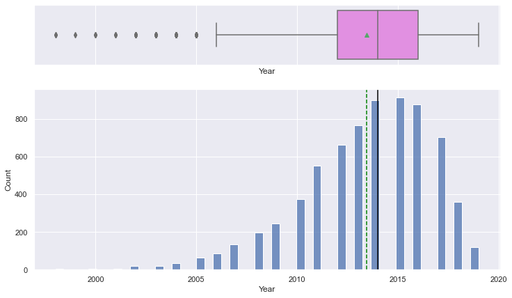

```python
histogram_boxplot(df,"Year")
```

- Data in the dataframe for the feature year is left skewed
- Averge number of used care in the year of 2013
- Outliers are noticed in the data frame for the feature Year

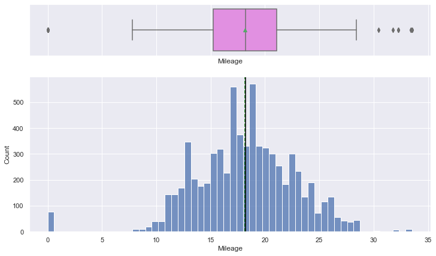

```python
histogram_boxplot(df,"Mileage")
```

- Data in the dataframe for the feature Mileage evenly distrubuted
- Averge miles given by the car is less than 20 miles
- Few Outliers are noticed in the data frame for the feature Mileage
- Mean and median values are same for the mileage offered by cars in the provided dataset

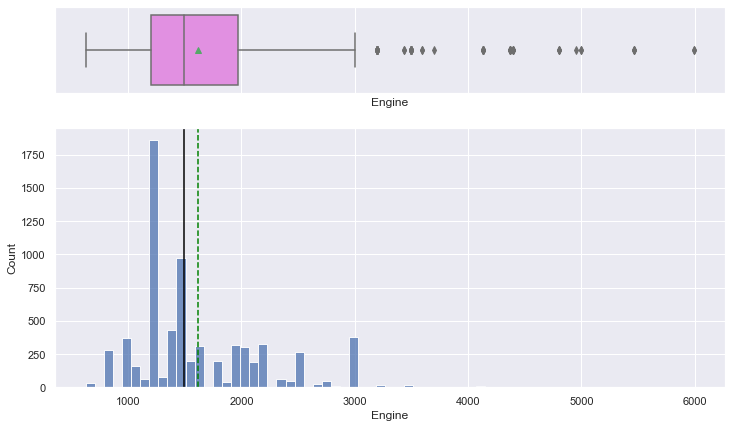

```python
histogram_boxplot(df,"Engine")
```

- Data in the dataframe for the feature Engine is right skewed
- Averge number CC of the engine is around 1500 to 1600
- Outliers are noticed in the data frame for the feature enigne
- Most of the outlier are right skewed

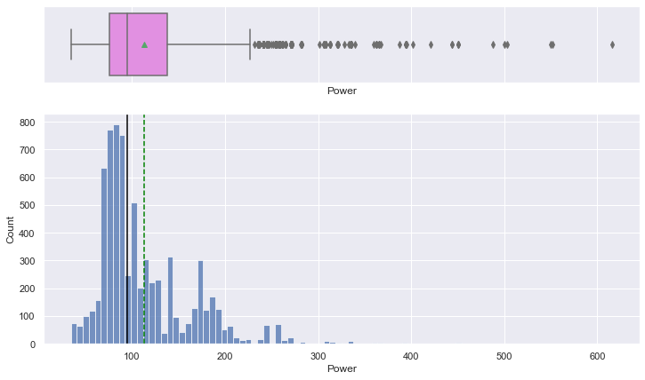

```python
histogram_boxplot(df,"Power")
```

- Data in the dataframe for the feature Power is right skewed
- Averge Horsepower of the car is around 100 to 120
- Outliers are noticed in the data frame for the feature Power
- Most of the outlier are right skewed

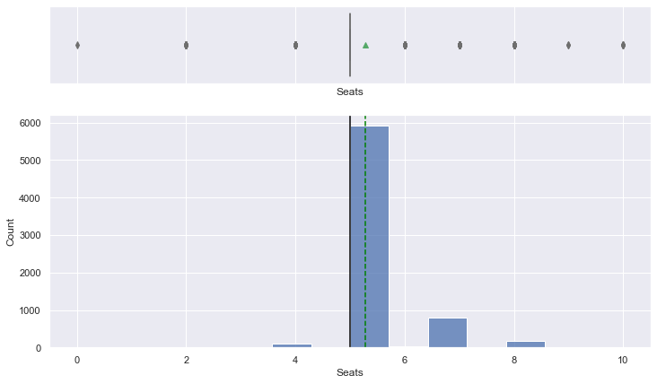

```python
histogram_boxplot(df,"Seats")
```

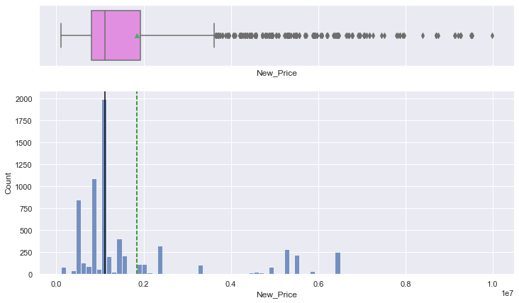

```python
histogram_boxplot(df,"New_Price")
```

- New car price varied and it has different price ranges
- Data in the dataframe for the feature new price is right skewed

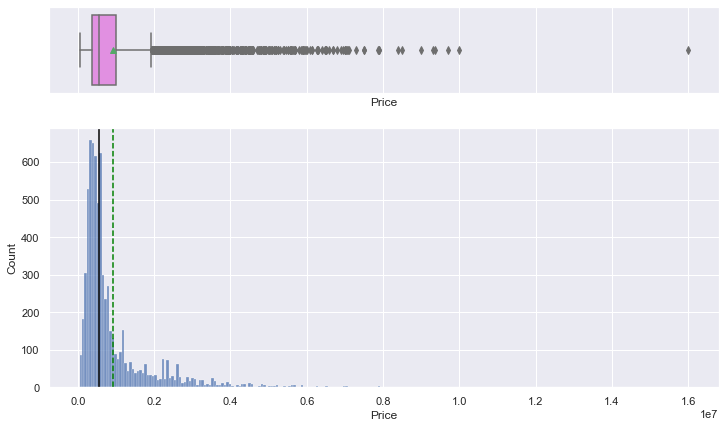

```python
histogram_boxplot(df,"Price")
```

- Car price varied and it has different price ranges
- Data in the dataframe for the feature new price is right skewed

```python
def labeled_barplot(data, feature, perc=False, n=None):
    """
    Barplot with percentage at the top

    data: dataframe
    feature: dataframe column
    perc: whether to display percentages instead of count (default is False)
    n: displays the top n category levels (default is None, i.e., display all levels)
    """

    total = len(data[feature])  # length of the column
    count = data[feature].nunique()
    if n is None:
        plt.figure(figsize=(count + 1, 5))
    else:
        plt.figure(figsize=(n + 1, 5))

    plt.xticks(rotation=90, fontsize=15)
    ax = sns.countplot(
        data=data,
        x=feature,
        palette="Paired",
        order=data[feature].value_counts().index[:n].sort_values(),
    )

    for p in ax.patches:
        if perc == True:
            label = "{:.1f}%".format(
                100 * p.get_height() / total
            )  # percentage of each class of the category
        else:
            label = p.get_height()  # count of each level of the category

        x = p.get_x() + p.get_width() / 2  # width of the plot
        y = p.get_height()  # height of the plot

        ax.annotate(
            label,
            (x, y),
            ha="center",
            va="center",
            size=12,
            xytext=(0, 5),
            textcoords="offset points",
        )  # annotate the percentage

    plt.show()  # show the plot
```

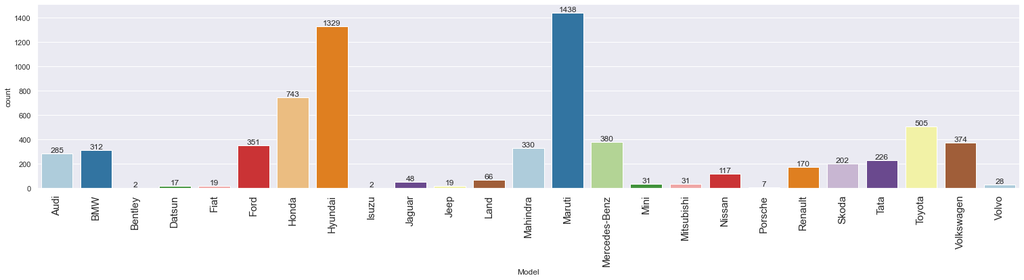

```python
labeled_barplot(df,"Model")
```

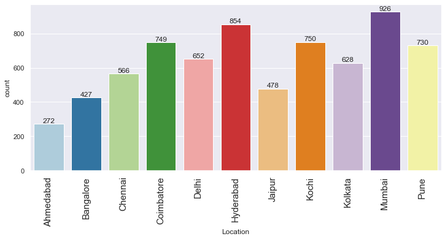

```python
labeled_barplot(df,"Location")
```

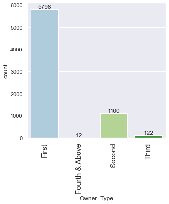

```python
labeled_barplot(df,"Owner_Type")
```

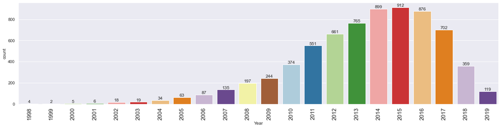

```python
labeled_barplot(df,"Year")
```

- Based on the above bar plot in most of the used cars are manfactured between years 2013 and 2017

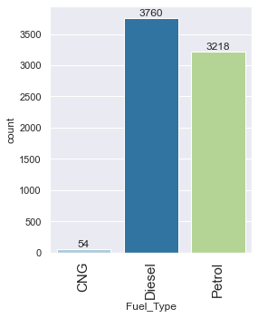

```python
labeled_barplot(df,"Fuel_Type")
```

- Based on the above viz. it is observed that in India, Diesel cars has highest demand

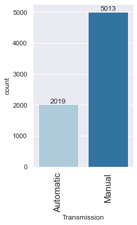

```python
labeled_barplot(df,"Transmission")
```

- Based on the above viz. it is observed that in India, most of the market is captured by Manual transmission

### Bivariate analysis

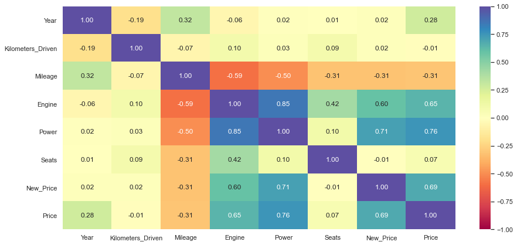

```python
plt.figure(figsize=(15, 7))
sns.heatmap(
    df.corr(), annot=True, vmin=-1, vmax=1, fmt=".2f", cmap="Spectral"
)
plt.show()
```

### Location vs Year

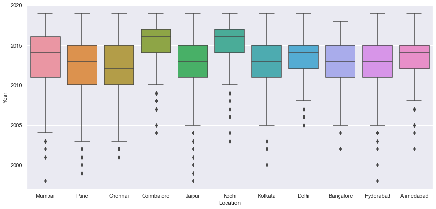

```python
plt.figure(figsize=(15,7)) # To resize the plot
# Visualizing data set using the barplot by gender and usage by grouping with product
#The box shows the quartiles of the dataset while the whiskers
#extend to show the rest of the distribution, except for points that are determined to be “outliers”
#using a method that is a function of the inter-quartile range
sns.boxplot(x='Location', y='Year', data=df)
plt.show()
```

- Based on the above box plot it is observed that most of the used cars sold in differnt cities are manfactured in between 2007 and 2019
- There are some outliers noticed that some cars that are manfactured before 2002 also in the inventory

### Owner type vs Year

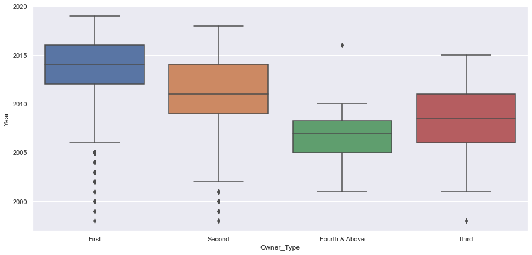

```python
plt.figure(figsize=(15,7)) # To resize the plot
# Visualizing data set using the barplot by gender and usage by grouping with product
#The box shows the quartiles of the dataset while the whiskers
#extend to show the rest of the distribution, except for points that are determined to be “outliers”
#using a method that is a function of the inter-quartile range
sns.boxplot(x='Owner_Type', y='Year', data=df)
plt.show()
```

### Model vs sum(Kilometers_Driven)

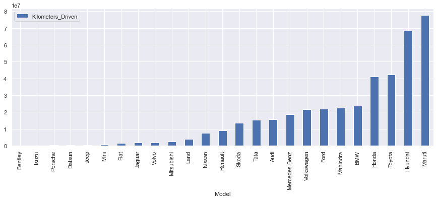

```python
# Show the bar chart by grouping Product and usage
df.groupby(by=['Model'])['Kilometers_Driven'].sum().reset_index().sort_values(['Kilometers_Driven']).plot(x='Model',
                                                                                                           y='Kilometers_Driven',
                                                                                                           kind='bar',
                                                                                                           figsize=(15,5))
plt.show()
```

- Based on the above bar plot it is observed that Maruti, Hyundai and Toyota has more number of kilometer driven

### Model vs Sum(New_Price)

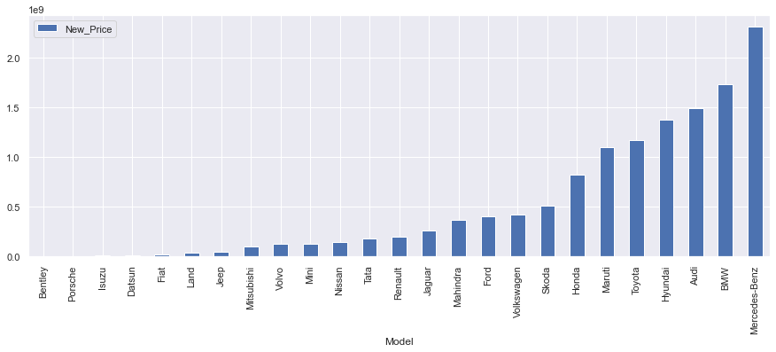

```python
# Show the bar chart by grouping Product and usage
df.groupby(by=['Model'])['New_Price'].sum().reset_index().sort_values(['New_Price']).plot(x='Model',
                                                                                                           y='New_Price',
                                                                                                           kind='bar',
                                                                                                           figsize=(15,5))
plt.show()
```

- Based on the above bar plot it is observed that customer spent more money on BMW, Hyundai, Audi and Benz

### Year vs Count

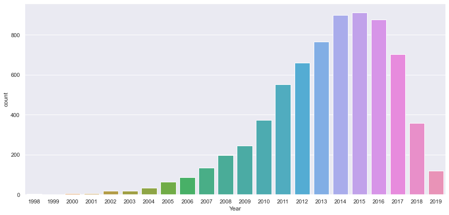

```python
plt.figure(figsize=(15,7)) # To resize the plot
# Plot which popular is more popular among customers
sns.countplot(x='Year', data=df)
plt.show()
```

- Based on the above count plot it is observed that most of the used cars are manfactured in the year 2012 till 2017

### Year vs count by Fuel type

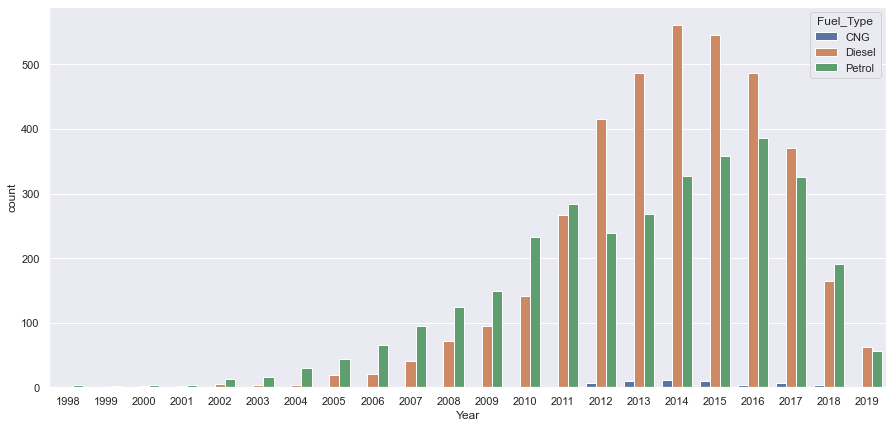

```python
plt.figure(figsize=(15,7)) # To resize the plot
# Plot which popular is more popular among customers
sns.countplot(x='Year', data=df, hue="Fuel_Type")
plt.show()
```

- Based on the above count plot it is observed that most of the used cars are manfactured in the year 2012 till 2017
- Diesel followed petrol are the most popular fuel type cars

### Year vs count by Owner Type

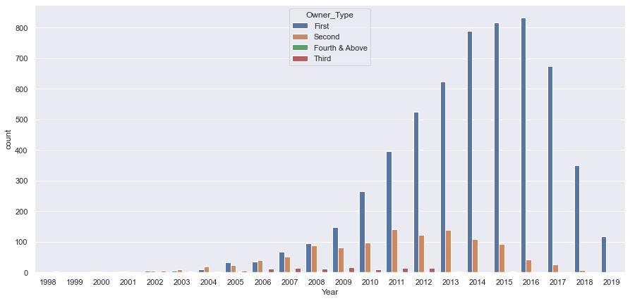

```python
plt.figure(figsize=(15,7)) # To resize the plot
# Plot which popular is more popular among customers
sns.countplot(x='Year', data=df, hue="Owner_Type")
plt.show()
```

- Based on the above count plot it is observed that most of the used cars are manfactured in the year 2012 till 2017
- First owner type is most popular

### Year vs Kilometers_Driven

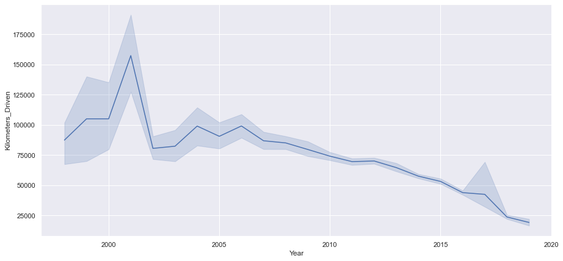

```python
plt.figure(figsize=(15,7)) # To resize the plot
# Plot which popular is more popular among customers
sns.lineplot(x="Year", y="Kilometers_Driven", data=df)
plt.show()
```

- Cars manfactured before 2002 has highest kilometers driven
- Based on the above line plot it is observed that cars manfactured from 2007 till 2009 also has more kilometers driven

```python
df.info()
```

```
<class 'pandas.core.frame.DataFrame'>
Int64Index: 7032 entries, 0 to 7252
Data columns (total 14 columns):
 #   Column             Non-Null Count  Dtype
---  ------             --------------  -----
 0   Name               7032 non-null   object
 1   Location           7032 non-null   object
 2   Year               7032 non-null   int64
 3   Kilometers_Driven  7032 non-null   int64
 4   Fuel_Type          7032 non-null   object
 5   Transmission       7032 non-null   object
 6   Owner_Type         7032 non-null   object
 7   Mileage            7032 non-null   float64
 8   Engine             7032 non-null   float64
 9   Power              7032 non-null   float64
 10  Seats              7032 non-null   float64
 11  New_Price          7032 non-null   float64
 12  Price              7032 non-null   float64
 13  Model              7032 non-null   object
dtypes: float64(6), int64(2), object(6)
memory usage: 1.1+ MB
```

## Model Building

- Dropping Name and Highly correlated features *Engine* and *Power*

```python
df.drop(["Name","Engine","Power"], axis=1, inplace=True)
```

```python
df.head()
```

|  | Location | Year | Kilometers_Driven | Fuel_Type | Transmission | Owner_Type | Mileage | Seats | New_Price | Price | Model |
| --- | --- | --- | --- | --- | --- | --- | --- | --- | --- | --- | --- |
| 0 | Mumbai | 2010 | 72000 | CNG | Manual | First | 26.60 | 5.0 | 554000.0 | 175000.0 | Maruti |
| 1 | Pune | 2015 | 41000 | Diesel | Manual | First | 19.67 | 5.0 | 1484000.0 | 1250000.0 | Hyundai |
| 2 | Chennai | 2011 | 46000 | Petrol | Manual | First | 18.20 | 5.0 | 861000.0 | 450000.0 | Honda |
| 3 | Chennai | 2012 | 87000 | Diesel | Manual | First | 20.77 | 7.0 | 1091000.0 | 600000.0 | Maruti |
| 4 | Coimbatore | 2013 | 40670 | Diesel | Automatic | Second | 15.20 | 5.0 | 5314000.0 | 1774000.0 | Audi |

### Define independent and dependent variables

```python
X = df.drop(['Price'], axis=1)
y = df['Price']
```

### Creating dummy variables

```python
X = pd.get_dummies(
    X,
    columns=X.select_dtypes(include=["object", "category"]).columns.tolist(),
    drop_first=True,
)
X.head()
```

|  | Year | Kilometers_Driven | Mileage | Seats | New_Price | Location_Bangalore | Location_Chennai | Location_Coimbatore | Location_Delhi | Location_Hyderabad | Location_Jaipur | Location_Kochi | Location_Kolkata | Location_Mumbai | Location_Pune | Fuel_Type_Diesel | Fuel_Type_Petrol | Transmission_Manual | Owner_Type_Fourth & Above | Owner_Type_Second | Owner_Type_Third | Model_BMW | Model_Bentley | Model_Datsun | Model_Fiat | Model_Ford | Model_Honda | Model_Hyundai | Model_Isuzu | … |
| --- | --- | --- | --- | --- | --- | --- | --- | --- | --- | --- | --- | --- | --- | --- | --- | --- | --- | --- | --- | --- | --- | --- | --- | --- | --- | --- | --- | --- | --- | --- |
| 0 | 2010 | 72000 | 26.60 | 5.0 | 554000.0 | 0 | 0 | 0 | 0 | 0 | 0 | 0 | 0 | 1 | 0 | 0 | 0 | 1 | 0 | 0 | 0 | 0 | 0 | 0 | 0 | 0 | 0 | 0 | 0 | … |
| 1 | 2015 | 41000 | 19.67 | 5.0 | 1484000.0 | 0 | 0 | 0 | 0 | 0 | 0 | 0 | 0 | 0 | 1 | 1 | 0 | 1 | 0 | 0 | 0 | 0 | 0 | 0 | 0 | 0 | 0 | 1 | 0 | … |
| 2 | 2011 | 46000 | 18.20 | 5.0 | 861000.0 | 0 | 1 | 0 | 0 | 0 | 0 | 0 | 0 | 0 | 0 | 0 | 1 | 1 | 0 | 0 | 0 | 0 | 0 | 0 | 0 | 0 | 1 | 0 | 0 | … |
| 3 | 2012 | 87000 | 20.77 | 7.0 | 1091000.0 | 0 | 1 | 0 | 0 | 0 | 0 | 0 | 0 | 0 | 0 | 1 | 0 | 1 | 0 | 0 | 0 | 0 | 0 | 0 | 0 | 0 | 0 | 0 | 0 | … |
| 4 | 2013 | 40670 | 15.20 | 5.0 | 5314000.0 | 0 | 0 | 1 | 0 | 0 | 0 | 0 | 0 | 0 | 0 | 1 | 0 | 0 | 0 | 1 | 0 | 0 | 0 | 0 | 0 | 0 | 0 | 0 | 0 | … |

```python
X.shape
```

```
(7032, 45)
```

### Split the data into train and test

```python
# splitting the data in 70:30 ratio for train to test data

x_train, x_test, y_train, y_test = train_test_split(X, y, test_size=0.3, random_state=1)
```

```python
print("Number of rows in train data =", x_train.shape[0])
print("Number of rows in test data =", x_test.shape[0])
```

```
Number of rows in train data = 4922
Number of rows in test data = 2110
```

### Fitting a linear model

```python
lin_reg_model = LinearRegression()
lin_reg_model.fit(x_train, y_train)
```

```
LinearRegression()
```

**Let us check the coefficients and intercept of the model, which are the parameters we learned.**

```python
coef_df = pd.DataFrame(
    np.append(lin_reg_model.coef_, lin_reg_model.intercept_),
    index=x_train.columns.tolist() + ["Intercept"],
    columns=["Coefficients"],
)
coef_df
```

|  | Coefficients |
| --- | --- |
| Year | 9.523614e+04 |
| Kilometers_Driven | 3.354721e-01 |
| Mileage | -3.834238e+04 |
| Seats | 3.389530e+03 |
| New_Price | 1.873766e-01 |
| Location_Bangalore | 1.642513e+05 |
| Location_Chennai | 1.110521e+05 |
| Location_Coimbatore | 1.868065e+05 |
| Location_Delhi | -2.952172e+04 |
| Location_Hyderabad | 1.140274e+05 |
| Location_Jaipur | 5.133189e+04 |
| Location_Kochi | -2.230102e+04 |
| Location_Kolkata | -6.170471e+04 |
| Location_Mumbai | -2.439311e+04 |
| Location_Pune | 2.868987e+04 |
| Fuel_Type_Diesel | -2.425586e+03 |
| Fuel_Type_Petrol | -1.916923e+05 |
| Transmission_Manual | -1.206612e+05 |
| Owner_Type_Fourth & Above | -9.760910e+03 |
| Owner_Type_Second | -5.358822e+04 |
| Owner_Type_Third | 1.031611e+04 |
| Model_BMW | 7.577940e+04 |
| Model_Bentley | 4.871640e+06 |
| Model_Datsun | -9.668143e+05 |
| Model_Fiat | -9.477889e+05 |
| Model_Ford | -7.597875e+05 |
| Model_Honda | -7.219083e+05 |
| Model_Hyundai | -7.823927e+05 |
| Model_Isuzu | -2.483864e+05 |
| Model_Jaguar | 1.152898e+06 |
| Model_Jeep | -2.052858e+05 |
| Model_Land | 2.124314e+06 |
| Model_Mahindra | -8.071201e+05 |
| Model_Maruti | -7.073156e+05 |
| Model_Mercedes-Benz | 3.574000e+03 |
| Model_Mini | 4.995060e+05 |
| Model_Mitsubishi | -8.332051e+05 |
| Model_Nissan | -8.839049e+05 |
| Model_Porsche | 1.970182e+06 |
| Model_Renault | -8.624053e+05 |
| Model_Skoda | -9.199362e+05 |
| Model_Tata | -9.281022e+05 |
| Model_Toyota | -6.282981e+05 |
| Model_Volkswagen | -8.535737e+05 |
| Model_Volvo | -4.062351e+05 |
| Intercept | -1.897696e+08 |

### Model performance check

- We will be using metric functions defined in sklearn for RMSE, MAE, and $R^2$.
- We will define functions to calculate adjusted $R^2$ and MAPE.
  - The mean absolute percentage error (MAPE) measures the accuracy of predictions as a percentage, and can be calculated as the average absolute percent error for each predicted value minus actual values divided by actual values. It works best if there are no extreme values in the data and none of the actual values are 0.
- We will create a function that will print out all the above metrics in one go.

```python
# function to compute adjusted R-squared
def adj_r2_score(predictors, targets, predictions):
    r2 = r2_score(targets, predictions)
    n = predictors.shape[0]
    k = predictors.shape[1]
    return 1 - ((1 - r2) * (n - 1) / (n - k - 1))


# function to compute MAPE
def mape_score(targets, predictions):
    return np.mean(np.abs(targets - predictions) / targets) * 100


# function to compute different metrics to check performance of a regression model
def model_performance_regression(model, predictors, target):
    """
    Function to compute different metrics to check regression model performance

    model: regressor
    predictors: independent variables
    target: dependent variable
    """

    # predicting using the independent variables
    pred = model.predict(predictors)

    r2 = r2_score(target, pred)  # to compute R-squared
    adjr2 = adj_r2_score(predictors, target, pred)  # to compute adjusted R-squared
    rmse = np.sqrt(mean_squared_error(target, pred))  # to compute RMSE
    mae = mean_absolute_error(target, pred)  # to compute MAE
    mape = mape_score(target, pred)  # to compute MAPE

    # creating a dataframe of metrics
    df_perf = pd.DataFrame(
        {
            "RMSE": rmse,
            "MAE": mae,
            "R-squared": r2,
            "Adj. R-squared": adjr2,
            "MAPE": mape,
        },
        index=[0],
    )

    return df_perf
```

```python
# Checking model performance on train set
print("Training Performance\n")
lin_reg_model_train_perf = model_performance_regression(lin_reg_model, x_train, y_train)
lin_reg_model_train_perf
```

```
Training Performance
```

|  | RMSE | MAE | R-squared | Adj. R-squared | MAPE |
| --- | --- | --- | --- | --- | --- |
| 0 | 563232.393329 | 295006.106052 | 0.710753 | 0.708084 | 48.50262 |

```python
# Checking model performance on test set
print("Test Performance\n")
lin_reg_model_test_perf = model_performance_regression(lin_reg_model, x_test, y_test)
lin_reg_model_test_perf
```

```
Test Performance
```

|  | RMSE | MAE | R-squared | Adj. R-squared | MAPE |
| --- | --- | --- | --- | --- | --- |
| 0 | 550184.406434 | 296061.362717 | 0.729271 | 0.723369 | 46.842606 |

## Conclusions

- We have been able to build a predictive model that can be used by Cars4U to predict the price of the used car with an $R^2$ of 0.71 on the training set.
- Cars4U can use this model to predict the price of the used car with an adjusted R-square of 72%
- We found that most 80% of data set for the feature new_price is null and filled with median value might impacted the some of the factors predicting the price of the used car